# Part II - Pima Indians Diabetes Dataset

## by (Chukwunonso E. Chukwumaeze)

## Investigation Overview

> In this investigation I aim to find out the most correlated variables with diabetes outcome in patients.

## Dataset Overview

> This dataset is originally from the National Institute of Diabetes and Digestive and Kidney Diseases, version was downloaded from Kaggle.

> The datasets consists of several medical predictor variables and one target variable, Outcome. Predictor variables includes the number of pregnancies the patient has had, their BMI, insulin level, age, and so on.

```python
# import all packages and set plots to be embedded inline
import numpy as np
import pandas as pd
import matplotlib.pyplot as plt
import seaborn as sns

%matplotlib inline

# suppress warnings from final output
import warnings
warnings.simplefilter("ignore")
```

```python
# load in the dataset into a pandas dataframe
df = pd.read_csv('diabetes.csv')
```

```python
# formatting columns to standard
df = df.rename(columns =lambda x: x.lower())
df.rename(columns={'outcome':'diabetes','diabetespedigreefunction' : 'diabetes_pedigree_function', 'bloodpressure':'blood_pressure','skinthickness':'skin_thickness'}, inplace=True)
```

```python
# changing diabetes to categorical datatype
from pandas.api.types import CategoricalDtype

cat = CategoricalDtype(categories=[0,1], ordered=True)
df.diabetes = df.diabetes.astype(cat)
```

> Note that the above cells have been set as "Skip"-type slides. That means that when the notebook is rendered as http slides, those cells won't show up.

## 1. Distribution of Diabetes Status

> **34.9% of participants have diabetes** while **65.1% do not have diabetes.**

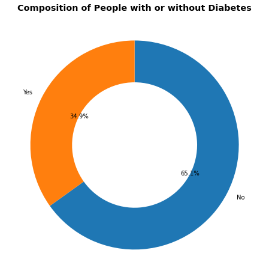

```python
# Creating a function for setting the size of figures
def size(x,y):
    plt.figure(figsize=[x,y])

outcomes = df.diabetes.value_counts()
size(10, 8)
plt.pie(outcomes, labels=['No','Yes'], startangle=90, autopct='%1.1f%%', counterclock=False, wedgeprops={'width':0.4});

plt.title("Composition of People with or without Diabetes", weight='bold', fontsize='x-large');
```

## 2. Are people with higher BMI more susceptible to diabetes?

> - Those **without diabetes** had a **median bmi of about 30** and an *IQR range of 25-35*
> - While those **with diabetes** had a **median bmi of about 35** and an *IQR range of about 31-39*

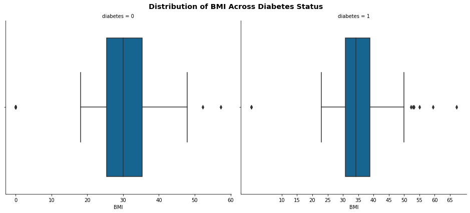

```python
plt.style.use('tableau-colorblind10')

g = sns.FacetGrid(data=df, col='diabetes', sharex=False, height=6, aspect=1.1)
g.map(sns.boxplot, 'bmi', order=[0,1]);

g.set(xlabel='BMI')

ticks = [x for x in range(10, 70, 5)]
labels = [f'{x}' for x in ticks]

plt.xticks(ticks, labels);

plt.subplots_adjust(top=0.9)
plt.suptitle('Distribution of BMI Across Diabetes Status', fontsize='x-large', weight='bold');
```

## 3. What is the relationship between the age and Diabetes Status of the participants?

> - Most people with diabetes were older than those without diabetes,
> - Most diabetic participants are around 30 years and 40 years as indicated by the distribution in the violinplot, with a larger population around the 30 year mark
> - The **median age of diabetic particpants around 36 years**
> - The **median age of nondiabetic participants is around 27 years**

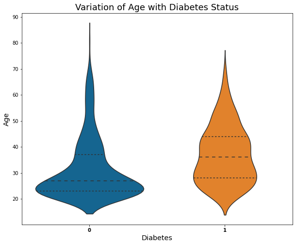

```python
size(10,8)
sns.violinplot(data=df, x='diabetes', y='age', alpha=0.6, inner='quartile');

plt.xlabel("Diabetes", fontsize='x-large', weight="4")
plt.ylabel("Age", fontsize='x-large', weight="4")

ticks = [0,1]
labels = ticks
plt.xticks(ticks, labels, weight='bold')

plt.title("Variation of Age with Diabetes Status", fontsize=18, weight=6);
```

## 4. What influence does Glucose and Insulin levels on Daibetes?

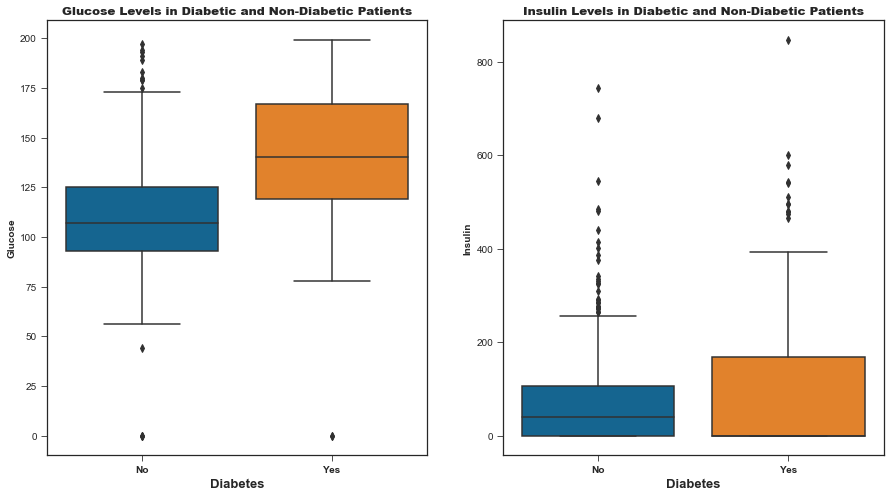

```python
bins = [-np.inf, 18.4, 24, 29, 34, 39, np.inf ]
labels = ['underweight','healthy-weight','overwieight','class-1-obesity','class-2-obesity','class-3-obesity']
df['bmi_category'] = pd.cut(df.bmi, bins=bins, labels=labels)


size(15,8)

plt.subplot(1,2,1)
plt.title('Glucose Levels in Diabetic and Non-Diabetic Patients', weight='heavy')
sns.boxplot(data=df, x='diabetes', y='glucose')
plt.ylabel('Glucose', weight='bold')
plt.xticks([0, 1], ["No", "Yes"], weight='bold');
plt.xlabel('Diabetes', weight='bold', fontsize=13)

plt.subplot(1,2,2)
plt.title('Insulin Levels in Diabetic and Non-Diabetic Patients', weight='heavy')
sns.boxplot(data=df, x='diabetes', y='insulin');
plt.ylabel('Insulin', weight='bold')
plt.xticks([0, 1], ["No", "Yes"], weight='bold');
plt.xlabel('Diabetes', weight='bold', fontsize=13);
```